# Reproducible Research: Peer Assessment 1

## Loading and preprocessing the data

```r
library(plyr)
library(lattice)
rawData <- read.csv("activity.csv")
```

## What is mean total number of steps taken per day?

First, we calculate the total number of steps taken each day and make a histogram.

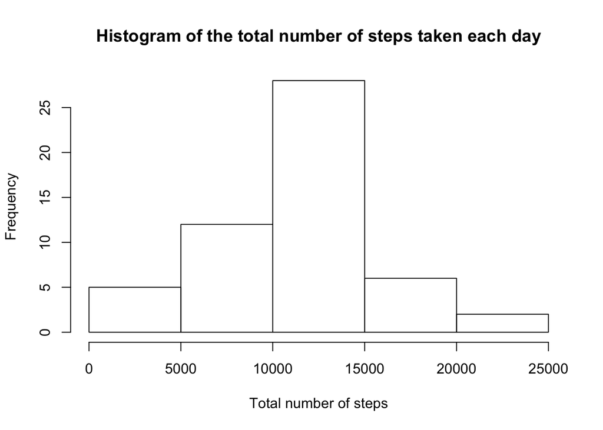

```r
totalDailySteps1 <- tapply(rawData$steps, rawData$date, sum)
hist(totalDailySteps1, main = "Histogram of the total number of steps taken each day", xlab = "Total number of steps")
```

Next, we calculate the mean and median total numbers of steps taken per day.

```r
meanDailySteps1 <- mean(totalDailySteps1, na.rm = TRUE)
medianDailySteps1 <- median(totalDailySteps1, na.rm = TRUE)
```

So the mean total numbers of steps taken per day is:

```
## [1] 10766
```

And the median total numbers of steps taken per day is :

```
## [1] 10765
```

## What is the average daily activity pattern?

First, we should remove the missing values.

```r
completedData <- complete.cases(rawData)
withoutNaData <- rawData[completedData,]
```

Then we should calculate the average number of steps taken per interval.

```r
averageIntervalSteps <- tapply(withoutNaData$steps, withoutNaData$interval, mean)
```

Then make the time series plot.

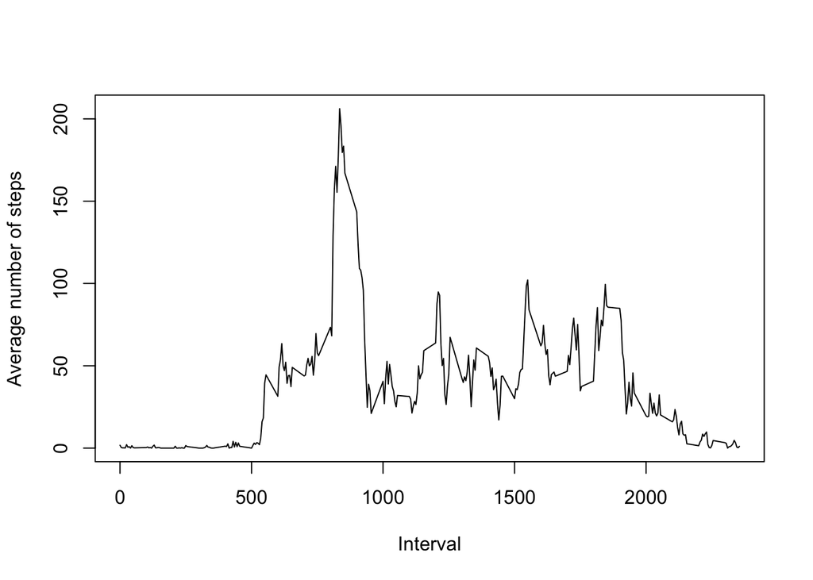

```r
averageIntervalSteps <- ldply(as.list(averageIntervalSteps), paste)
names(averageIntervalSteps) <- c("interval", "averagesteps")
averageIntervalSteps$interval <- as.numeric(averageIntervalSteps$interval)
averageIntervalSteps$averagesteps <- as.numeric(averageIntervalSteps$averagesteps)
plot(averageIntervalSteps$interval, averageIntervalSteps$averagesteps,
     type = "l", xlab = "Interval", ylab = "Average number of steps")
```

So, the 5-minute interval that contains the maximum number of step is :

```
## [1] 835
```

## Imputing missing values

First, we should calculate the the total number of missing values.

```r
amountMissingValues <- nrow(rawData) - nrow(withoutNaData)
```

So the total number of missing values is :

```r
print (amountMissingValues)
```

```
## [1] 2304
```

Then we create a dataset filling in all of the missing values with int **1**.

```r
for (i in 1:nrow(rawData)) {
        if (is.na(rawData$steps[i])) {
                rawData$steps[i] = 1
                as.integer(rawData$steps[i])
        }
}
```

Next, we make a histogram of the total number of steps taken each day.

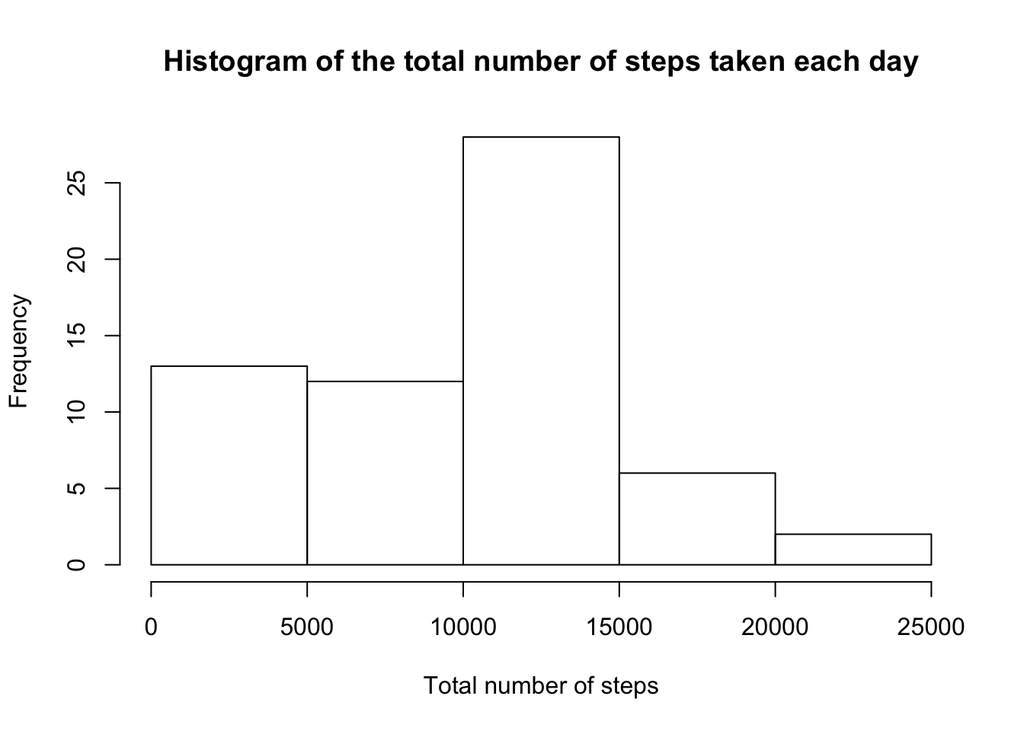

```r
totalDailySteps2 <- tapply(rawData$steps, rawData$date, sum)
hist(totalDailySteps2, main = "Histogram of the total number of steps taken each day", xlab = "Total number of steps")
```

And calculate the mean and median total number of steps taken per day.

```r
meanDailySteps2 <- mean(totalDailySteps2, na.rm = TRUE)
medianDailySteps2 <- mean(totalDailySteps2, na.rm = TRUE)
```

So the mean total numbers of steps taken per day is:

```
## [1] 9392
```

```
## [1] 9392
```

## Are there differences in activity patterns between weekdays and weekends?

First, we create a new factor varible in the dataset with two levels - “weekday” and “weekend”.

```r
weekdayData <- weekdays(as.Date(rawData$date))
for (i in 1:length(weekdayData)) {
        if (weekdayData[i] == "星期六" | weekdayData[i] == "星期日") {
                weekdayData[i] = "Weekend"
        } else {
                weekdayData[i] = "Weekday"
        }
}
rawData$weekdayData <- as.factor(weekdayData)
```

Make a panel plot containing a time series plot of the 5-minute interval (x-axis) and the average number of steps taken, averaged across all weekday days or weekend days (y-axis).

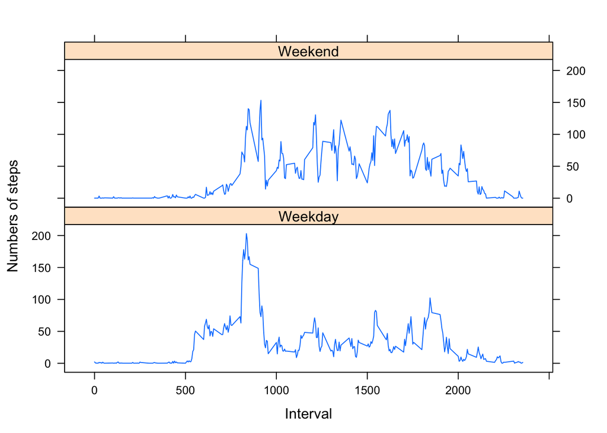

```r
weekdaysData <- rawData[rawData$weekdayData == "Weekday",]
weekdayAverageSteps <- tapply(weekdaysData$steps, weekdaysData$interval, mean)
weekdayAverageSteps <- ldply(as.list(weekdayAverageSteps), paste)
names(weekdayAverageSteps) <- c("interval", "steps")
weekdayAverageSteps$weekdayData <- "Weekday"

weekendData <- rawData[rawData$weekdayData == "Weekend",]
weekendAverageSteps <- tapply(weekendData$steps, weekendData$interval, mean)
weekendAverageSteps <- ldply(as.list(weekendAverageSteps), paste)
names(weekendAverageSteps) <- c("interval", "steps")
weekendAverageSteps$weekdayData <- "Weekend"

avergeSteps <- data.frame()
avergeSteps <- rbind(avergeSteps, weekdayAverageSteps)
avergeSteps <- rbind(avergeSteps, weekendAverageSteps)
avergeSteps$interval <- as.numeric(avergeSteps$interval)
avergeSteps$steps <- as.numeric(avergeSteps$steps)
avergeSteps$weekdayData <- as.factor(avergeSteps$weekdayData)

xyplot(avergeSteps$steps ~ avergeSteps$interval | avergeSteps$weekdayData, layout = c(1,2), xlab = "Interval", ylab = "Numbers of steps",
       panel = function(x, y){
               panel.xyplot(x, y, type = "l")
       })
```